# deplink: compares the genetic/epigenetic features between cancer cell lines with different dependencies of a gene set (signature)

Xiao Chen Columbia University Medical Center

2020-11-11

# Abstract

‘deplink’ compares the genetic/epigenetic features between cancer cell lines with highest and lowest dependencies of a gene set (signature).

## Install deplink

```r
##  Install deplink in R (>= 3.5.0)
library(devtools)
install_github("seanchen607/deplink")
```

## Load deplink and data libraries

Data source: [DepMap](https://depmap.org/portal/) *(release 2019q4)* and [CCLE](https://portals.broadinstitute.org/ccle)

```r
## load package
library(deplink)

## load data libraries
source(system.file("script", "load_libs.R", package = "deplink"))
```

## All-in-one analysis

For example, deplink compares the genetic/epigenetic features between cancer cell lines with highest and lowest dependencies of “9-1-1” complex members:

```r
deplink(signature.name = "9-1-1", signature = c("RAD9A", "RAD1", "HUS1", "RAD17"))
```

The results will be output to a local directory (default: root directory) under a folder in name of the designated “signature.name” (“9-1-1” in this case).

Several cutoffs are set by default as below and can be changed by will. Please see the help page for more details (*?deplink*).

```r
cutoff.freq        = 10
cutoff.percentile  = 0.2
cutoff.pvalue      = 0.05
cutoff.qvalue      = 0.1
cutoff.diff        = 0.1
cutoff.fc          = 2
```

The comparison covers the following features:

- Genomic/epigenetic features
  - Genetic dependency
  - Gene expression
  - Chromatin modification
- Genome instability
  - Genetic mutation
  - COSMIC signature
  - Tumor mutation burden (TMB)
  - Copy number variation (CNV)
  - Microsatellite instability (MSI)
- Drug sensitivity
  - Drug sensitivity from GDSC data set
  - Drug sensitivity from PRISM data set
- Immune infiltration
  - Immune signature gene (ISG)
- Stemness
  - mRNA stemness index (mRNAsi)
  - Epithelial–mesenchymal transition (EMT)
- Misc.
  - Cancer type

## Individual analysis

deplink can compare individual genetic/epigenetic feature between cancer cell lines with highest and lowest dependencies of a gene set (signature). For example of “9-1-1” complex members:

```r
## "9-1-1" complex members as a gene set (signature)
signature.name = "9-1-1"
signature = c("RAD9A", "RAD1", "HUS1", "RAD17")
```

### Cancer type component

‘cancertypeHigh’ displays the cancer type component of cell lines with high dependencies of a gene set (signature).

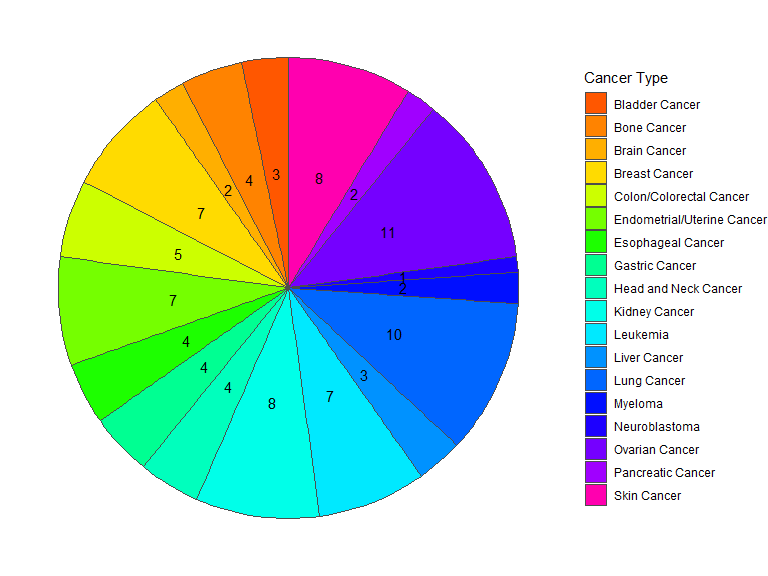

```r
## display the cancer type component of cell lines with high dependencies of "9-1-1" complex
cancertypeHigh(signature.name, signature)
```

‘cancertypeLow’ displays the cancer type component of cell lines with low dependencies of a gene set (signature).

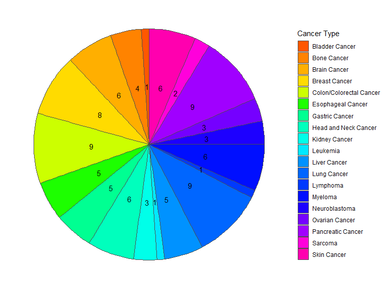

```r
## display the cancer type component of cell lines with low dependencies of "9-1-1" complex
cancertypeLow(signature.name, signature)
```

‘cancertypeLandscape’ displays the landscape of cancer type component of cell lines with different dependencies of a gene set (signature).

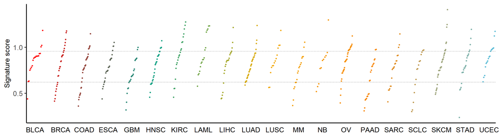

```r
## display the landscape of cancer type component of cell lines with different dependencies of "9-1-1" complex
cancertypeLandscape(signature.name, signature)
```

### Genetic dependency

‘dependency’ compares the genetic dependency between cancer cell lines with highest and lowest dependencies of a gene set (signature).

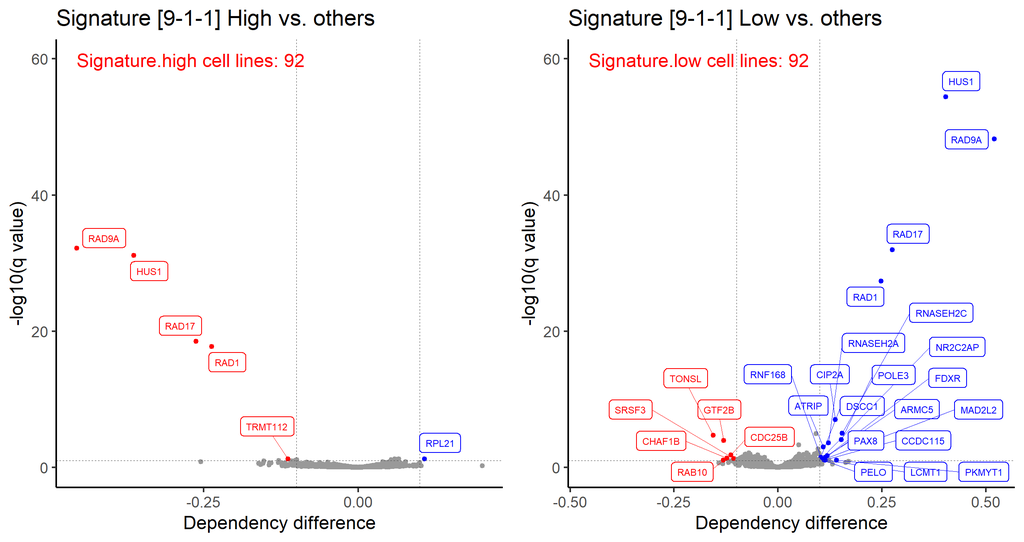

```r
## compare the genetic dependency between cancer cell lines with highest and lowest dependencies of "9-1-1" complex
dependency(signature.name, signature)
```

### Gene expression

‘expressions’ compares the gene expression between cancer cell lines with highest and lowest dependencies of a gene set (signature).

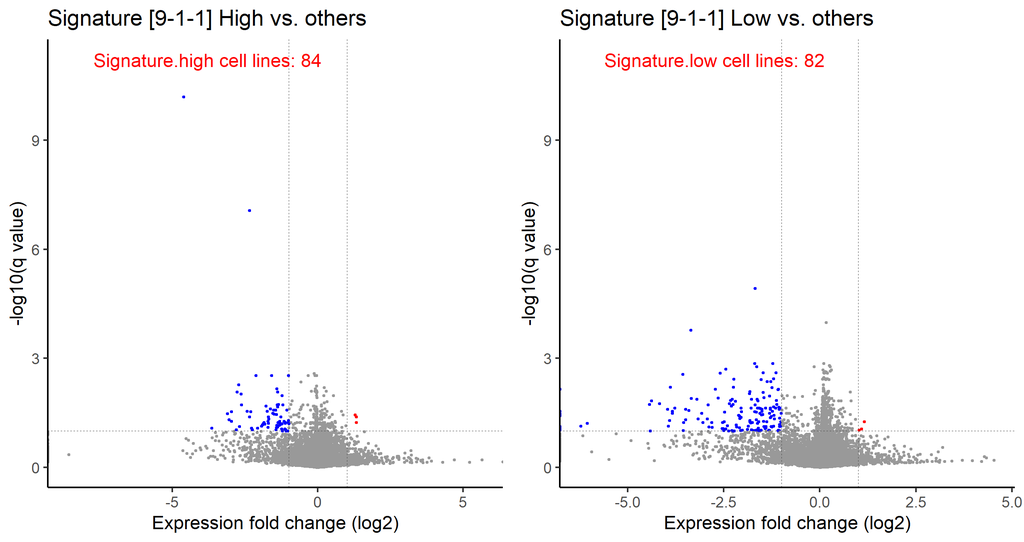

```r
## compare the gene expression between cancer cell lines with highest and lowest dependencies of "9-1-1" complex
expressions(signature.name, signature)
```

### Chromatin modification

‘chromatinModification’ compares the chromatin modification abundance between cancer cell lines with highest and lowest dependencies of a gene set (signature).

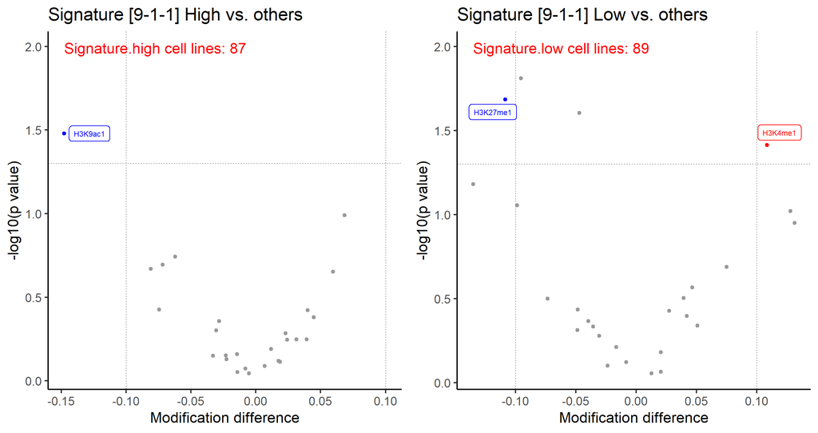

```r
## compare the chromatin modification abundance between cell lines with highest and lowest dependencies of "9-1-1" complex
chromatinModification(signature.name, signature)
```

### Genetic mutation

‘mutations’ compares the genetic mutations between cancer cell lines with highest and lowest dependencies of a gene set (signature).

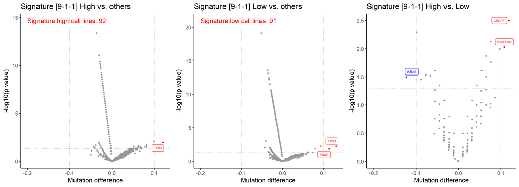

```r
## compare the genetic mutations between cancer cell lines with highest and lowest dependencies of "9-1-1" complex
mutations(signature.name, signature)
```

### COSMIC signature

‘cosmic’ compares the COSMIC signatures between cell lines with highest and lowest dependencies of a gene set (signature).

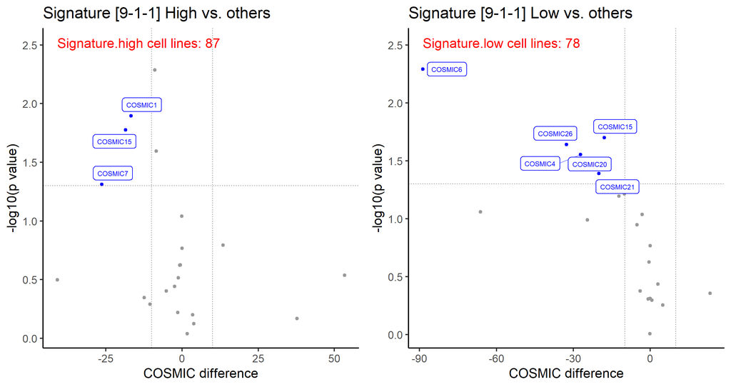

```r
## compare the COSMIC signatures between cell lines with highest and lowest dependencies of "9-1-1" complex
cosmic(signature.name, signature)
```

### Tumor mutation burden (TMB)

‘tmb’ compares the tumor mutation burden (TMB) between cancer cell lines with highest and lowest dependencies of a gene set (signature).

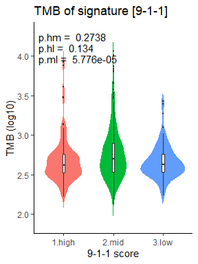

```r
## compare the tumor mutation burden (TMB) between cancer cell lines with highest and lowest dependencies of "9-1-1" complex
tmb(signature.name, signature)
```

### Copy number variation (CNV)

‘cnv’ compares the copy number variation (CNV) between cancer cell lines with highest and lowest dependencies of a gene set (signature).

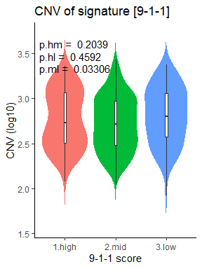

```r
## compare the copy number variation (CNV) between cancer cell lines with highest and lowest dependencies of "9-1-1" complex
cnv(signature.name, signature)
```

### Microsatellite instability (MSI)

‘msi’ compares the microsatellite instability (MSI) between cancer cell lines with highest and lowest dependencies of a gene set (signature).

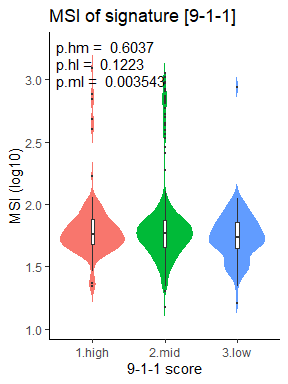

```r
## compare the microsatellite instability (MSI) between cancer cell lines with highest and lowest dependencies of "9-1-1" complex
msi(signature.name, signature)
```

### Drug sensitivity

‘drugGDSC’ compares the drug sensitivity (GDSC dataset) between cancer cell lines with highest and lowest dependencies of a gene set (signature).

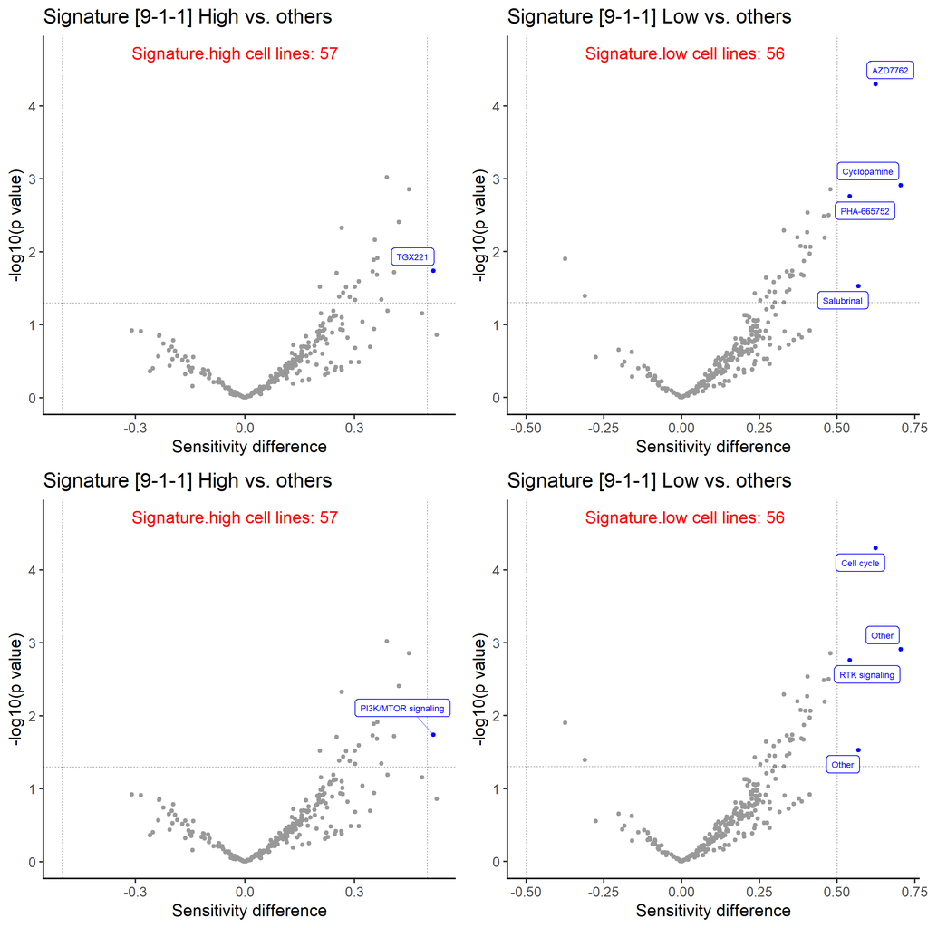

```r
## compare the drug sensitivity (GDSC dataset) between cancer cell lines with highest and lowest dependencies of "9-1-1" complex
drugGDSC(signature.name, signature)
```

‘drugPRISM’ compares the drug sensitivity (PRISM dataset) between cancer cell lines with highest and lowest dependencies of a gene set (signature).

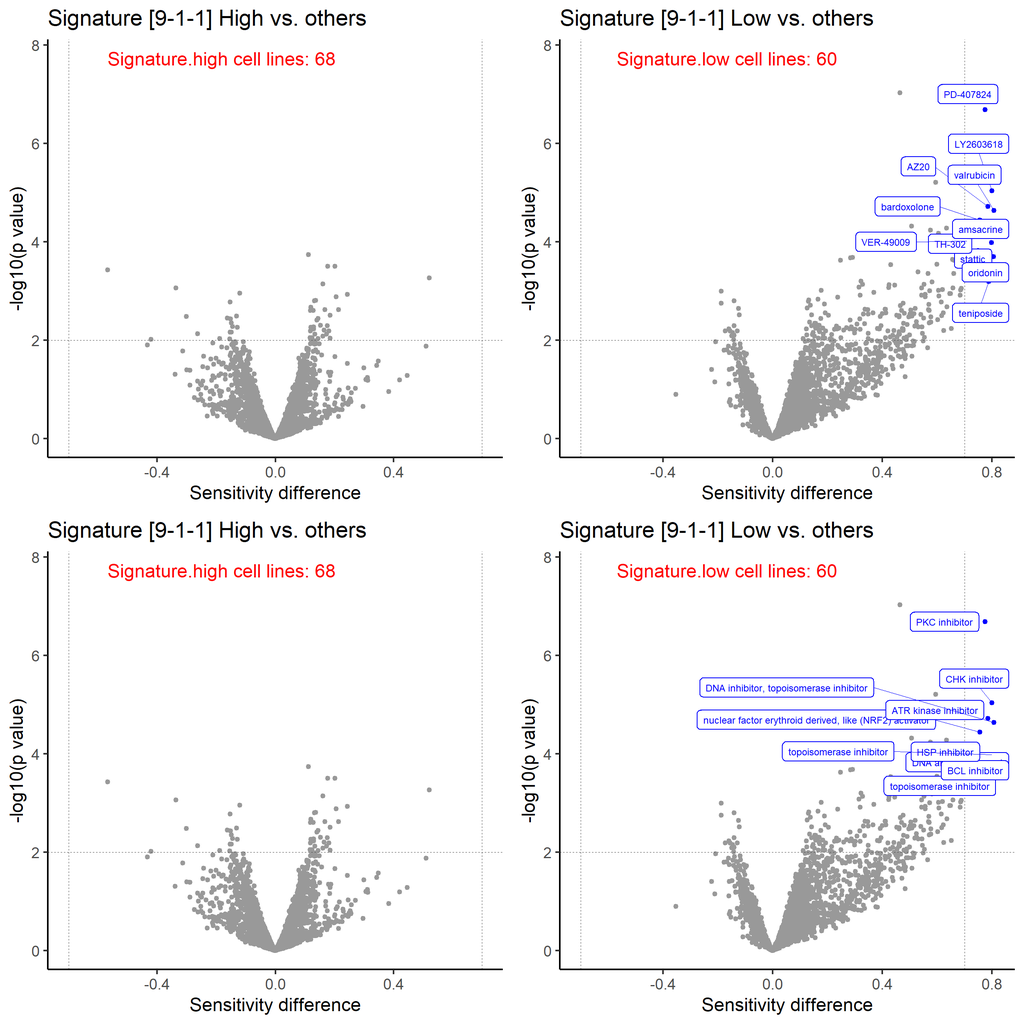

```r
## compare the drug sensitivity (PRISM dataset) between cancer cell lines with highest and lowest dependencies of "9-1-1" complex
drugPRISM(signature.name, signature)
```

### Immune signature gene (ISG)

‘isg’ compares the immune signature gene (ISG) between cancer cell lines with highest and lowest dependencies of a gene set (signature).

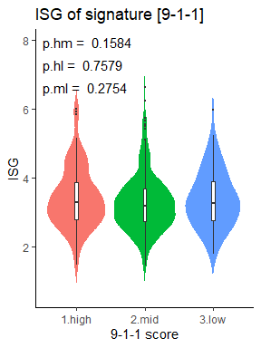

```r
## compare the immune signature gene (ISG) between cancer cell lines with highest and lowest dependencies of "9-1-1" complex
isg(signature.name, signature)
```

### mRNA stemness index (mRNAsi)

‘mrnasi’ compares the mRNA stemness index (mRNAsi) between cancer cell lines with highest and lowest dependencies of a gene set (signature).

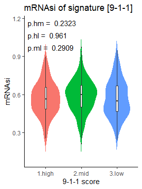

```r
## compare the mRNA stemness index (mRNAsi) between cancer cell lines with highest and lowest dependencies of "9-1-1" complex
mrnasi(signature.name, signature)
```

### Epithelial–mesenchymal transition (EMT)

‘emt’ compares the epithelial–mesenchymal transition (EMT) between cancer cell lines with highest and lowest dependencies of a gene set (signature).

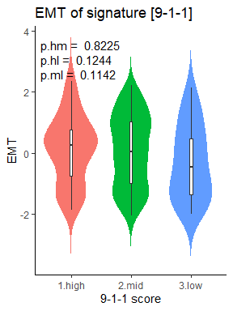

```r
## compare the epithelial–mesenchymal transition (EMT) between cancer cell lines with highest and lowest dependencies of "9-1-1" complex
emt(signature.name, signature)
```

### Hallmark signature score

‘hallmark’ compares the Hallmark signature score between cancer cell lines with highest and lowest dependencies of a gene set (signature).

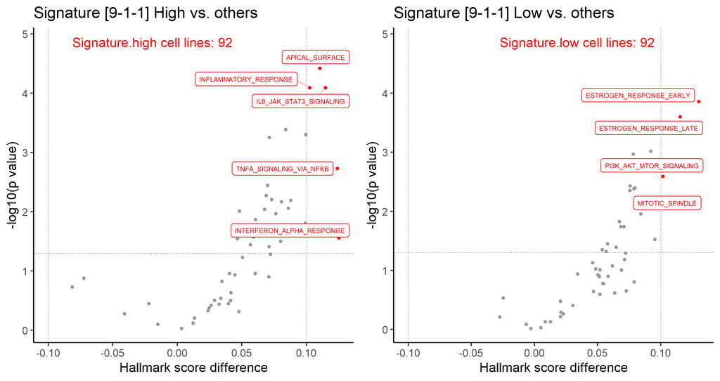

```r
## compare the Hallmark signatures between cell lines with highest and lowest dependencies of "9-1-1" complex
hallmark(signature.name, signature)
```

# Citation

If you use deplink in published research, please cite the most appropriate paper(s) from this list:

1. **X Chen**, J McGuire, F Zhu, X Xu, Y Li, D Karagiannis, R Dalla-Favera, A Ciccia, J Amengual & C Lu (2020). Harnessing genetic dependency correlation network to reveal chromatin vulnerability in cancer. *In preparation*.